# Introduction to Quantum GIS (QGIS) a free, open source GIS tool

Leah A. Wasser (adapted from Julien Brun’s work!!)

### Learning outcomes

At the end of this 30 minute overview you will be able to:

- Add vector data to QGIS
- Add raster data to QGIS
- Explore the metadata - CRS, resolution, extent of a spatial data layer in QGIS
- Create a basic map in QGIS

## Intro to Quantum GIS (QGIS)

[figure not shown]

QGIS logo

[QGIS](http://www.qgis.org/en/site/) is a free and open GIS tool that can be used across many different platforms. You can think of it as ESRI’s ArcGIS but it plays nicely with MACs and PC’s!

QGIS is:

- Cross-platform
- Open source
- Free

QGIS is an ideal tool to explore geospatial data. Naturally it can also be used for geospatial processing and analysis however keep in mind that these workflows can also be performed in R and Python and make even **more reproducible**!

NOTE: you can script QGIS analysis in Python.

You can do just about anything you can do with ArcGIS in QGIS including:

1. data visualization and exploration
2. Make maps
3. Edit / Manipulate / create and save new data

# Harness greater powers

- Interface to GRASS GIS
  - Full-fledged analytical GIS environment
- Run many GDAL/OGR utilities
  - Swiss army knife for geospatial data

# QGIS plugins

QGIS is an open source product and as with many open source, tools, there are people constantly creating new features via PLUGINS to this tool. To install a plugin, use the Plugins drop down and select manage and install plugins. You will then see a list of plugins - similar to the list below.

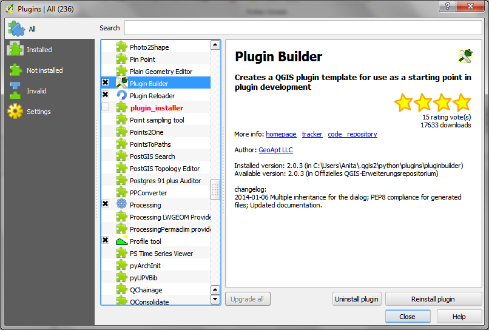

QGIS plugins

A few favorite plugins:

- **Value tool:** A MUST if you work with raster data. use this to view the value of a pixel in a raster dataset like you would the identify tool in ArcMap.
- **MapSwipeTool:** A cool tool if you want to view before/ after rasters and look at differences.

Note: that there is also a python console tool that can be used to add command line access to the tool.

## Challenge

Create a map of the Gulf of mexico.